# Nigeria_Africa_Intra-Trade_Analysis

2024-07-10

To boost trade among African countries, regional economic communities (RECs), such as ECOWAS, have been created over the last few decades. Trade among African countries only accounts for about 10 per cent of their total external trade according to UN.org report.

The challenges of improving such low levels of intra-African trade are immense, but policymakers on the continent are increasingly focusing on them as a new wave of interest in regional integration gains momentum.

This descriptive report analysis task therefore, is to examine the Nigeria intra-Africa trade connectedness for the year 2019.

```r
#load the libraries
library(tidyverse)
library(janitor)
#load the data set into R
commerce1 <- read.csv("D:/DDrive - Document/R_Tutoria_365/nigeria_intra_Africa_trade_connectedness.csv")
head(commerce1) # view first few rows of the data set
```

```
##   exporting_country_iso       commodities importing_country_iso commodity_index
## 1                   nga   Abrasive Powder                   ner             100
## 2                   nga  Acrylic Polymers                   ner             100
## 3                   nga  Activated Carbon                   ner             100
## 4                   nga Agglomerated Cork                   ben             100
## 5                   nga  Air Conditioners                   ner             100
## 6                   nga         Air Pumps                   ner             100
##   trade_value contig comlang_off comcol     dist  distcap scaled_sci
## 1    84063569      1           0      0 802.7985 736.6656     117965
## 2    84063569      1           0      0 802.7985 736.6656     117965
## 3    84063569      1           0      0 802.7985 736.6656     117965
## 4   116353441      1           0      0 105.1806 568.2081      88778
## 5    84063569      1           0      0 802.7985 736.6656     117965
## 6    84063569      1           0      0 802.7985 736.6656     117965
##   importing_total_import commodities_code  supply  demand commodities_count
```

[output cut: 27 more lines]

Let’s explore the structure and dimensions of the data set

```r
dim(commerce1)
```

```
## [1] 47127    28
```

```r
str(commerce1)
```

```
## 'data.frame':    47127 obs. of  28 variables:
##  $ exporting_country_iso   : chr  "nga" "nga" "nga" "nga" ...
##  $ commodities             : chr  "Abrasive Powder" "Acrylic Polymers" "Activated Carbon" "Agglomerated Cork" ...
##  $ importing_country_iso   : chr  "ner" "ner" "ner" "ben" ...
##  $ commodity_index         : num  100 100 100 100 100 100 100 100 100 100 ...
##  $ trade_value             : num  8.41e+07 8.41e+07 8.41e+07 1.16e+08 8.41e+07 ...
##  $ contig                  : int  1 1 1 1 1 1 1 1 1 1 ...
##  $ comlang_off             : int  0 0 0 0 0 0 0 0 0 0 ...
##  $ comcol                  : int  0 0 0 0 0 0 0 0 0 0 ...
##  $ dist                    : num  803 803 803 105 803 ...
##  $ distcap                 : num  737 737 737 568 737 ...
##  $ scaled_sci              : int  117965 117965 117965 88778 117965 117965 117965 117965 117965 117965 ...
##  $ importing_total_import  : int  925 925 925 1027 925 925 925 925 925 925 ...
##  $ commodities_code        : int  136805 73906 63802 94504 168415 168414 178803 42207 62912 157604 ...
##  $ supply                  : num  410 238 3662 601 223944 ...
##  $ demand                  : num  29299 2304918 32882 1175 3915794 ...
##  $ commodities_count       : int  827 827 827 900 827 827 827 827 827 827 ...
##  $ export_value            : num  NA NA NA 514 NA NA NA NA NA NA ...
##  $ exporting_country       : chr  "Nigeria" "Nigeria" "Nigeria" "Nigeria" ...
##  $ exporting_gdp           : num  4.48e+11 4.48e+11 4.48e+11 4.48e+11 4.48e+11 ...
##  $ exporting_gdp_per_capita: num  2230 2230 2230 2230 2230 ...
##  $ exporting_recs          : chr  "CENSAD; ECOWAS" "CENSAD; ECOWAS" "CENSAD; ECOWAS" "CENSAD; ECOWAS" ...
##  $ exporting_region        : chr  "Western Africa" "Western Africa" "Western Africa" "Western Africa" ...
##  $ importing_country       : chr  "Niger" "Niger" "Niger" "Benin" ...
##  $ importing_gdp           : num  1.29e+10 1.29e+10 1.29e+10 1.44e+10 1.29e+10 ...
##  $ importing_gdp_per_capita: num  554 554 554 1219 554 ...
##  $ importing_recs          : chr  "CENSAD; ECOWAS" "CENSAD; ECOWAS" "CENSAD; ECOWAS" "CENSAD; ECOWAS" ...
##  $ importing_region        : chr  "Western Africa" "Western Africa" "Western Africa" "Western Africa" ...
##  $ year                    : int  2019 2019 2019 2019 2019 2019 2019 2019 2019 2019 ...
```

```r
summary(commerce1) #summary(base) gives a summary information about each of the columns highlighting missing values per column and calculates the summary statistics of the numeric columns
```

```
##  exporting_country_iso commodities        importing_country_iso
##  Length:47127          Length:47127       Length:47127
##  Class :character      Class :character   Class :character
##  Mode  :character      Mode  :character   Mode  :character
##
##
##
##
##  commodity_index   trade_value            contig         comlang_off
##  Min.   : 38.11   Min.   :3.353e+04   Min.   :0.00000   Min.   :0.0000
##  1st Qu.: 84.64   1st Qu.:1.647e+05   1st Qu.:0.00000   1st Qu.:0.0000
##  Median : 90.41   Median :3.024e+06   Median :0.00000   Median :0.0000
##  Mean   : 88.40   Mean   :2.750e+08   Mean   :0.07187   Mean   :0.4332
##  3rd Qu.: 93.00   3rd Qu.:1.493e+07   3rd Qu.:0.00000   3rd Qu.:1.0000
##  Max.   :100.00   Max.   :4.042e+09   Max.   :1.00000   Max.   :1.0000
##  NA's   :2488     NA's   :5854
##      comcol            dist           distcap         scaled_sci
##  Min.   :0.0000   Min.   : 105.2   Min.   : 568.2   Min.   :  1787
##  1st Qu.:0.0000   1st Qu.:1694.2   1st Qu.:1717.0   1st Qu.:  8494
##  Median :0.0000   Median :3099.3   Median :2825.9   Median : 16443
##  Mean   :0.3167   Mean   :2939.2   Mean   :2889.4   Mean   : 23462
##  3rd Qu.:1.0000   3rd Qu.:4060.8   3rd Qu.:3911.0   3rd Qu.: 27978
##  Max.   :1.0000   Max.   :6610.8   Max.   :6405.3   Max.   :117965
##                                                     NA's   :2488
##  importing_total_import commodities_code     supply
##  Min.   : 704           Min.   : 10102   Min.   :2.000e+00
##  1st Qu.: 997           1st Qu.: 62935   1st Qu.:4.094e+03
##  Median :1082           Median :115809   Median :3.545e+04
##  Mean   :1060           Mean   :111270   Mean   :5.215e+07
##  3rd Qu.:1144           3rd Qu.:158308   3rd Qu.:3.563e+05
##  Max.   :1210           Max.   :219706   Max.   :4.600e+10
##
##      demand          commodities_count  export_value       exporting_country
##  Min.   :1.000e+00   Min.   :650.0     Min.   :1.000e+00   Length:47127
##  1st Qu.:4.533e+04   1st Qu.:882.0     1st Qu.:1.300e+02   Class :character
##  Median :4.300e+05   Median :928.0     Median :8.320e+02   Mode  :character
##  Mean   :1.090e+07   Mean   :912.1     Mean   :2.995e+06
##  3rd Qu.:3.277e+06   3rd Qu.:961.0     3rd Qu.:9.042e+03
##  Max.   :8.930e+09   Max.   :996.0     Max.   :3.616e+09
##                                        NA's   :43220
```

[output cut: 9 more lines]

```
##  Length:47127       Length:47127       Min.   :4.186e+08
##  Class :character   Class :character   1st Qu.:4.942e+09
##  Mode  :character   Mode  :character   Median :1.439e+10
##                                        Mean   :4.111e+10
##                                        3rd Qu.:3.901e+10
##                                        Max.   :3.514e+11
##                                        NA's   :758
##  importing_gdp_per_capita importing_recs     importing_region        year
##  Min.   :  261.2          Length:47127       Length:47127       Min.   :2019
##  1st Qu.:  709.5          Class :character   Class :character   1st Qu.:2019
##  Median : 1446.8          Mode  :character   Mode  :character   Median :2019
##  Mean   : 2694.2                                                Mean   :2019
##  3rd Qu.: 3317.5                                                3rd Qu.:2019
##  Max.   :17448.3                                                Max.   :2019
##  NA's   :758
```

Exploring the data further confirms Nigeria is the only exporting country. This also helps us identify the relevant and non relevant columns.

```r
unique(commerce1$exporting_country) #Nigeria is the only exporting country
```

```
## [1] "Nigeria"
```

```r
unique(commerce1$exporting_region)
```

```
## [1] "Western Africa"
```

```r
unique(commerce1$exporting_recs)
```

```
## [1] "CENSAD; ECOWAS"
```

```r
unique(commerce1$exporting_gdp_per_capita)
```

```
## [1] 2229.859 2229.859
```

```r
unique(commerce1$exporting_gdp)
```

```
## [1] 448120428859
```

Having seen that the above columns provides only one data value about Nigeria, it will be removed, along with other columns that are not needed for this report

```r
commerce_cols_cl <- commerce1 %>%
  select(-c(exporting_country_iso,importing_country_iso, commodity_index, commodities_code,export_value,
            exporting_country,exporting_gdp,exporting_gdp_per_capita, exporting_recs,exporting_region, year))
```

Check irrelevant columns have been removed.

```r
names(commerce_cols_cl)
```

```
##  [1] "commodities"              "trade_value"
##  [3] "contig"                   "comlang_off"
##  [5] "comcol"                   "dist"
##  [7] "distcap"                  "scaled_sci"
##  [9] "importing_total_import"   "supply"
## [11] "demand"                   "commodities_count"
## [13] "importing_country"        "importing_gdp"
## [15] "importing_gdp_per_capita" "importing_recs"
## [17] "importing_region"
```

Next is to deal with missing value. Since this data is about understanding the intra trade activities of Nigeria with other countries in the continent, it is better to remove rows of country where the trade value is missing and NAs in the Scale Sci column.

```r
commerce_NA_cl <- commerce_cols_cl %>%
  filter(!is.na(trade_value) & !is.na(scaled_sci) )
summary(commerce_NA_cl) #check to see the cleaned data set
```

```
##  commodities         trade_value            contig         comlang_off
##  Length:40382       Min.   :3.353e+04   Min.   :0.00000   Min.   :0.0000
##  Class :character   1st Qu.:3.977e+05   1st Qu.:0.00000   1st Qu.:0.0000
##  Mode  :character   Median :3.571e+06   Median :0.00000   Median :0.0000
##                     Mean   :2.810e+08   Mean   :0.08387   Mean   :0.4425
##                     3rd Qu.:3.309e+07   3rd Qu.:0.00000   3rd Qu.:1.0000
##                     Max.   :4.042e+09   Max.   :1.00000   Max.   :1.0000
##      comcol            dist           distcap         scaled_sci
##  Min.   :0.0000   Min.   : 105.2   Min.   : 568.2   Min.   :  1787
##  1st Qu.:0.0000   1st Qu.:1433.9   1st Qu.:1700.4   1st Qu.:  9378
##  Median :0.0000   Median :3073.3   Median :2747.1   Median : 16332
##  Mean   :0.3032   Mean   :2754.2   Mean   :2740.6   Mean   : 24710
##  3rd Qu.:1.0000   3rd Qu.:3909.5   3rd Qu.:3596.6   3rd Qu.: 28073
##  Max.   :1.0000   Max.   :6610.8   Max.   :6405.3   Max.   :117965
##  importing_total_import     supply              demand
##  Min.   : 774           Min.   :2.000e+00   Min.   :1.000e+00
##  1st Qu.:1017           1st Qu.:3.980e+03   1st Qu.:5.343e+04
##  Median :1103           Median :3.536e+04   Median :4.996e+05
##  Mean   :1075           Mean   :5.352e+07   Mean   :1.200e+07
##  3rd Qu.:1147           3rd Qu.:3.532e+05   3rd Qu.:3.686e+06
##  Max.   :1210           Max.   :4.600e+10   Max.   :8.930e+09
##  commodities_count importing_country  importing_gdp
##  Min.   :728.0     Length:40382       Min.   :4.186e+08
##  1st Qu.:895.0     Class :character   1st Qu.:7.667e+09
##  Median :939.0     Mode  :character   Median :1.599e+10
##  Mean   :921.8                        Mean   :4.588e+10
##  3rd Qu.:968.0                        3rd Qu.:5.209e+10
##  Max.   :996.0                        Max.   :3.514e+11
##  importing_gdp_per_capita importing_recs     importing_region
##  Min.   :  261.2          Length:40382       Length:40382
##  1st Qu.:  786.9          Class :character   Class :character
##  Median : 1507.5          Mode  :character   Mode  :character
##  Mean   : 2930.0
##  3rd Qu.: 3603.8
##  Max.   :17448.3
```

Next in cleaning this data is to rename countries with miss spelt names

```r
unique_country_names<- unique(commerce_NA_cl$importing_country) # extract the country names to identify wrong names
unique_country_names
```

```
##  [1] "Niger"               "Benin"               "Togo"
##  [4] "Liberia"             "Ghana"               "C?te d?Ivoire"
##  [7] "Equatorial Guinea"   "Botswana"            "Kenya"
## [10] "Zambia"              "Sierra Leone"        "Congo - Brazzaville"
## [13] "Namibia"             "Gambia"              "Cameroon"
## [16] "South Africa"        "Tanzania"            "Uganda"
## [19] "Chad"                "Gabon"               "Eswatini"
## [22] "Mali"                "Burkina Faso"        "S?o Tom? & Pr?ncipe"
## [25] "Burundi"             "Guinea"              "Senegal"
## [28] "Malawi"              "Libya"               "Congo - Kinshasa"
## [31] "Rwanda"              "Guinea-Bissau"       "Seychelles"
## [34] "Zimbabwe"            "Mauritius"           "Angola"
## [37] "Mauritania"          "Madagascar"          "Cape Verde"
## [40] "Morocco"             "Egypt"               "Tunisia"
## [43] "Ethiopia"            "Algeria"
```

```r
commerce_NA_cl <- commerce_NA_cl %>%
  mutate(importing_country = recode(importing_country,
                          "C?te d?Ivoire" = "Côte d'Ivoire",
                          "S?o Tom? & Pr?ncipe" = "Sao Tome and Principe")
         )
commerce_NA_cl <- commerce_NA_cl %>% # 1 country did not correct,because of special character "?" ,
#using the gsub function to rename country below
  mutate(importing_country = gsub("S\\?o Tom\\? & Pr\\?ncipe", "Sao Tome and Principe", importing_country))
```

```r
unique(commerce_NA_cl$importing_country) # check that the names are now correct
```

```
##  [1] "Niger"                 "Benin"                 "Togo"
##  [4] "Liberia"               "Ghana"                 "Côte d'Ivoire"
##  [7] "Equatorial Guinea"     "Botswana"              "Kenya"
## [10] "Zambia"                "Sierra Leone"          "Congo - Brazzaville"
## [13] "Namibia"               "Gambia"                "Cameroon"
## [16] "South Africa"          "Tanzania"              "Uganda"
## [19] "Chad"                  "Gabon"                 "Eswatini"
## [22] "Mali"                  "Burkina Faso"          "Sao Tome and Principe"
## [25] "Burundi"               "Guinea"                "Senegal"
## [28] "Malawi"                "Libya"                 "Congo - Kinshasa"
## [31] "Rwanda"                "Guinea-Bissau"         "Seychelles"
## [34] "Zimbabwe"              "Mauritius"             "Angola"
## [37] "Mauritania"            "Madagascar"            "Cape Verde"
## [40] "Morocco"               "Egypt"                 "Tunisia"
## [43] "Ethiopia"              "Algeria"
```

```r
commerce_NA_cl[which.max(commerce_NA_cl$trade_value),]
```

```
##     commodities trade_value contig comlang_off comcol     dist  distcap
## 102      Cobalt  4042239315      0           1      1 423.4102 913.1168
##     scaled_sci importing_total_import supply demand commodities_count
## 102      66630                   1172   1431 121248               978
##     importing_country importing_gdp importing_gdp_per_capita importing_recs
## 102             Ghana   66983634224                 2202.116 CENSAD; ECOWAS
##     importing_region
## 102   Western Africa
```

```r
#get the minimum and max trade value rowwise to see full column details about that country
commerce_NA_cl[which.min(commerce_NA_cl$trade_value),]
```

```
##       commodities trade_value contig comlang_off comcol     dist  distcap
## 29141      Cobalt       33535      0           1      0 3909.526 3478.486
##       scaled_sci importing_total_import supply demand commodities_count
## 29141       3263                   1078   1431  60681               921
##       importing_country importing_gdp importing_gdp_per_capita importing_recs
## 29141          Ethiopia   95912590628                 855.7609   COMESA; IGAD
##       importing_region
## 29141   Eastern Africa
```

The same product was least traded with Ethiopia, at a paltry amount of N33,535.

## Regional and Economic Community Analysis

Analyzing trade patterns by region and economic communities, lets organize country by trade value in desc order and then summarize the data by importing country.

```r
trade_by_importingC <- commerce_NA_cl %>%
  group_by(importing_country) %>%
  summarise(total_trade_value = sum(trade_value)) %>%
  arrange(desc(total_trade_value))
head(trade_by_importingC)
```

```
## # A tibble: 6 × 2
##   importing_country total_trade_value
##   <chr>                         <dbl>
## 1 Ghana                 3953310050070
## 2 South Africa          3632335332900
## 3 Côte d'Ivoire         1375985781720
## 4 Cameroon               808604327440
## 5 Angola                 540229218678
## 6 Senegal                402766689202
```

```r
#get the percentage of the each country over total trade
trade_by_importingC2 <- trade_by_importingC %>%
  mutate(percentage = round(total_trade_value/sum(total_trade_value)*100,1))
head(trade_by_importingC2)
```

```
## # A tibble: 6 × 3
##   importing_country total_trade_value percentage
##   <chr>                         <dbl>      <dbl>
## 1 Ghana                 3953310050070       34.8
## 2 South Africa          3632335332900       32
## 3 Côte d'Ivoire         1375985781720       12.1
## 4 Cameroon               808604327440        7.1
## 5 Angola                 540229218678        4.8
## 6 Senegal                402766689202        3.5
```

```r
#sum the total % share of the 10 importing countries
sum(trade_by_importingC2$percentage[1:10])
```

```
## [1] 98.8
```

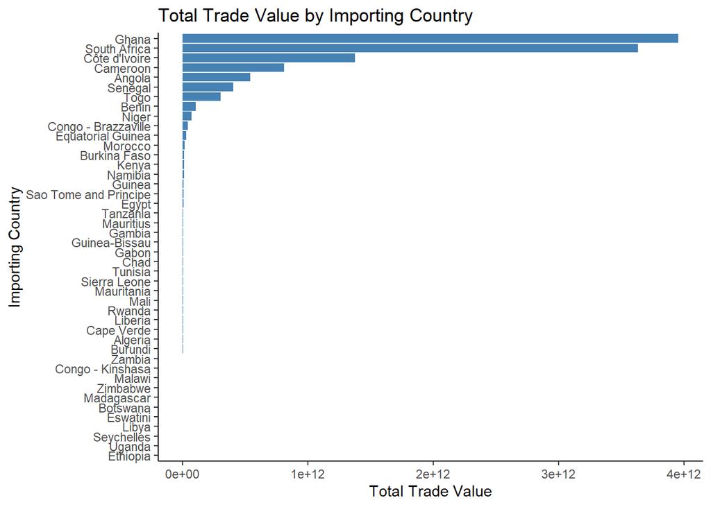

```r
#visualize the data
plot_importingC <- ggplot(trade_by_importingC, aes(x = reorder(importing_country, total_trade_value), y = total_trade_value))+
  geom_bar(stat = "identity", fill ="steelblue") +
  coord_flip()+
  ggtitle("Total Trade Value by Importing Country")+
  xlab("Importing Country")+
  ylab("Total Trade Value")+
  theme_classic()
plot_importingC
```

The above graph shows Ghana is the highest importing country from Nigeria

```r
# For clearer visual, lets look at the top 10 importing country
top_10_importing_country <- trade_by_importingC %>%
  top_n(10, wt = total_trade_value)
head(top_10_importing_country)
```

```
## # A tibble: 6 × 2
##   importing_country total_trade_value
##   <chr>                         <dbl>
## 1 Ghana                 3953310050070
## 2 South Africa          3632335332900
## 3 Côte d'Ivoire         1375985781720
## 4 Cameroon               808604327440
## 5 Angola                 540229218678
## 6 Senegal                402766689202
```

```r
# Lets add the % of trade each for each country within the top10 group
top_10_importing_country <- top_10_importing_country %>%
  mutate(percentage = total_trade_value/sum(total_trade_value)*100)
View(top_10_importing_country)
sum(top_10_importing_country$percentage)
```

```
## [1] 100
```

Visualize the data

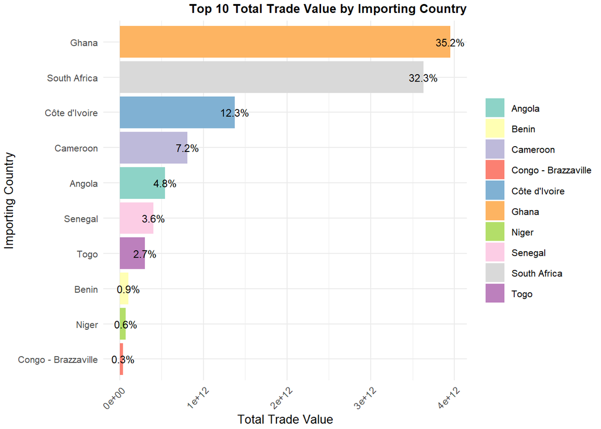

```r
plot_top10_C <- ggplot(top_10_importing_country, aes(x = reorder(importing_country, total_trade_value), y = total_trade_value, fill = importing_country)) +
  geom_bar(stat = "identity") +
  geom_text(aes(label = paste0(round(percentage, 1), "%")),
            position = position_stack(vjust = 1),
            size = 3,
            color = "black") +
  coord_flip() +
  ggtitle("Top 10 Total Trade Value by Importing Country") +
  xlab("Importing Country") +
  ylab("Total Trade Value") +
  scale_fill_brewer(palette = "Set3") +  # Adjust color palette if needed
  theme_minimal(base_size = 10) +  # Set base font size for better readability
  theme(axis.text.x = element_text(angle = 45, hjust = 1),
        plot.title = element_text(size = 10, face = "bold", hjust = 1),  # Center align title
        legend.position = "right",  # Move legend to the right
        legend.title = element_blank(),  # Remove legend title
        legend.text = element_text(size = 8),  # Adjust legend text size
        plot.margin = margin(0.1, 0.1, 0.1, 0.1, "cm"))  # Add some padding around the plot

plot_top10_C
```

The plot above reveals that the top 10 importing country made up 98.8% of the total export trading activity of Nigeria in 2019. Ghana topped the list (35.2%), followed by South Africa (32.3%)

```r
#For clearer visual, lets also get the bottom10 importing countries
bottom_10_importing_country <- trade_by_importingC %>%
  slice_min(order_by = total_trade_value, n = 10)
view(bottom_10_importing_country)
```

```r
# Lets add the % of trade each for each country within the bottom10 group
bottom_10_ICbypercent <- bottom_10_importing_country %>%
  mutate(percentage = round(total_trade_value/sum(total_trade_value)*100,1))
view(bottom_10_ICbypercent)
```

Inversely, below graph shows the bottom 10 countries Nigeria traded with. Ethiopia and Uganda made the top bottom at 4.2% and 4.6% traded value respectively.

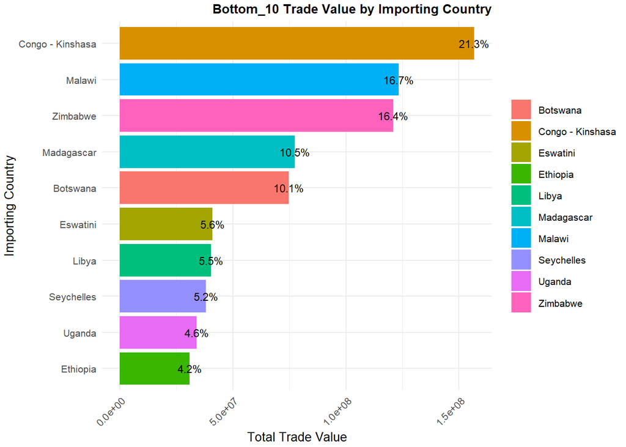

```r
#visualize the bottom_10 importing countries
plot_bottom10_C <- ggplot(bottom_10_ICbypercent, aes(x = reorder(importing_country, total_trade_value), y = total_trade_value, fill = importing_country)) +
  geom_bar(stat = "identity") +
  geom_text(aes(label = paste0(round(percentage, 1), "%")),
            position = position_stack(vjust = 1),
            size = 3,
            color = "black") +
  coord_flip() +
  ggtitle("Bottom_10 Trade Value by Importing Country") +
  xlab("Importing Country") +
  ylab("Total Trade Value") +
  #scale_fill_brewer(palette = "Set3") +  # Adjust color palette if needed
  theme_minimal(base_size = 10) +  # Set base font size for better readability
  theme(axis.text.x = element_text(angle = 45, hjust = 1),
        plot.title = element_text(size = 10, face = "bold", hjust = 1),  # Center align title
        legend.position = "right",  # Move legend to the right
        legend.title = element_blank(),  # Remove legend title
        legend.text = element_text(size = 8),  # Adjust legend text size
        plot.margin = margin(0.1, 0.1, 0.1, 0.1, "cm"))  # Add some padding around the plot

plot_bottom10_C
```

```r
# Trade values by importing region
trade_by_importing_region <- commerce_NA_cl %>%
  group_by(importing_region) %>%
  summarize(total_trade_value = sum(trade_value))
view(trade_by_importing_region)
```

```r
#get the % of the share of the region
trade_by_importing_region <- trade_by_importing_region %>%
  mutate(percentage = round(total_trade_value/sum(total_trade_value)*100,1))
view(trade_by_importing_region)
```

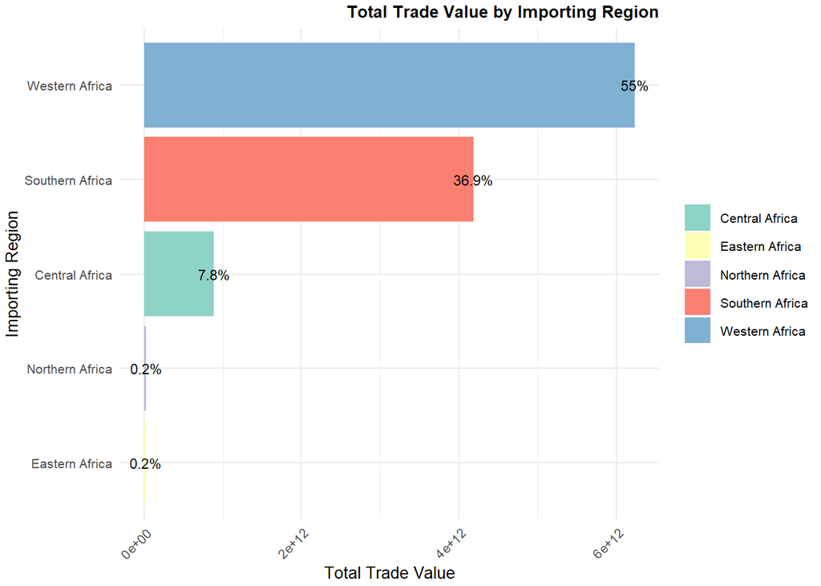

```r
#visualize the data
TV_by_ImportingR <- ggplot(trade_by_importing_region, aes(x = reorder(importing_region, total_trade_value), y = total_trade_value, fill = importing_region)) +
  geom_bar(stat = "identity") +
  geom_text(aes(label = paste0(round(percentage, 1), "%")),
            position = position_stack(vjust = 1),
            size = 3,
            color = "black") +
  coord_flip() +
  ggtitle("Total Trade Value by Importing Region") +
  xlab("Importing Region") +
  ylab("Total Trade Value") +
  scale_fill_brewer(palette = "Set3") +  # Adjust color palette if needed
  theme_minimal(base_size = 10) +  # Set base font size for better readability
  theme(axis.text.x = element_text(angle = 45, hjust = 1),
        plot.title = element_text(size = 10, face = "bold", hjust = 1),  # Center align title
        legend.position = "right",  # Move legend to the right
        legend.title = element_blank(),  # Remove legend title
        legend.text = element_text(size = 8),  # Adjust legend text size
        plot.margin = margin(0.1, 0.1, 0.1, 0.1, "cm"))  # Add some padding around the plot

TV_by_ImportingR
```

```r
# Analyse trade by the importing RECs
#summarize by importing recs
trade_by_importing_recs <- commerce_NA_cl %>%
  group_by(importing_recs) %>%
  summarize(total_trade_value = sum(trade_value))
view(trade_by_importing_recs)
```

```r
#get the % share of each recs over total trade value
Importing_recsPerc <- trade_by_importing_recs %>%
  mutate(percentage = round(total_trade_value/sum(total_trade_value)*100,1)) %>%
arrange(desc(percentage))
view(Importing_recsPerc)
```

```r
#get top recs for, slice and sum
sum(Importing_recsPerc$percentage[1:4]) # the top 4 recs makes up 99.5% of the trade.
```

```
## [1] 99.5
```

```r
top_4_importing_recs <- Importing_recsPerc %>%
  top_n(4, wt = total_trade_value)
View(top_4_importing_recs)
```

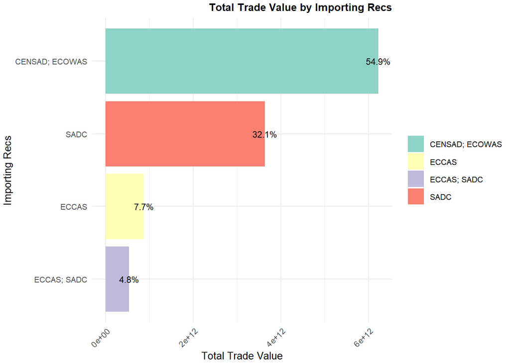

```r
#visualize the data
  TV_by_ImportingRec <- ggplot(top_4_importing_recs, aes(x = reorder(importing_recs, total_trade_value), y = total_trade_value, fill = importing_recs)) +
    geom_bar(stat = "identity") +
    geom_text(aes(label = paste0(round(percentage, 1), "%")),
              position = position_stack(vjust = 1),
              size = 3,
              color = "black") +
    coord_flip() +
    ggtitle("Total Trade Value by Importing Recs") +
    xlab("Importing Recs") +
    ylab("Total Trade Value") +
    scale_fill_brewer(palette = "Set3") +  # Adjust color palette if needed
    theme_minimal(base_size = 10) +  # Set base font size for better readability
    theme(axis.text.x = element_text(angle = 45, hjust = 1),
          plot.title = element_text(size = 10, face = "bold", hjust = 1),  # Center align title
          legend.position = "right",  # Move legend to the right
          legend.title = element_blank(),  # Remove legend title
          legend.text = element_text(size = 8),  # Adjust legend text size
          plot.margin = margin(0.1, 0.1, 0.1, 0.1, "cm"))  # Add some padding around the plot

TV_by_ImportingRec
```

## Distance and Connectivity Analysis

Lets now analyze the impact of distance and connectivity on trade values.

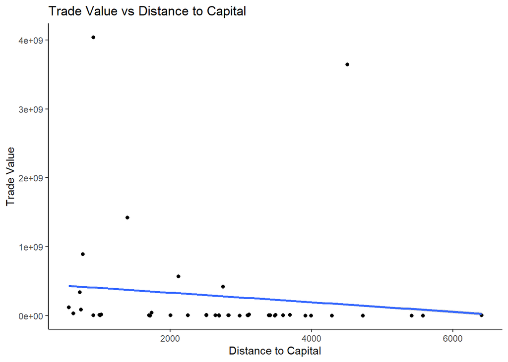

```r
#Trade value vs distance to capital
TV_by_distcap <- ggplot(commerce_NA_cl, aes(x = distcap, y = trade_value)) +
  geom_point(alpha = 0.5) +
  geom_smooth(method = "lm")+
  ggtitle("Trade Value vs Distance to Capital") +
  labs(x= "Distance to Capital", y ="Trade Value")+
  theme_classic()
 TV_by_distcap # this represent distance to the country's capital
```

As seen above, there is negative correlation between distance to capital and its impact on the trading activity with Nigeria. The longer the distance, the lesser the trade value except for South Africa which is an outlier to this trend.

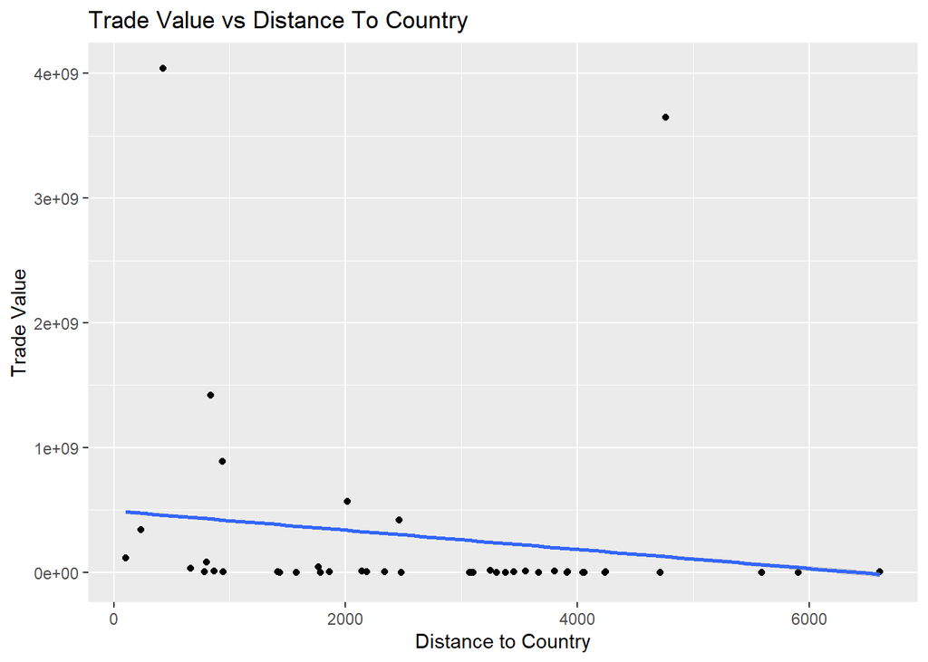

```r
#Trade value vs distance to country
TV_by_dist <- ggplot(commerce_NA_cl, aes(x = dist, y = trade_value)) +
  geom_point(alpha = 0.5) +
  geom_smooth(method = "lm")+
  ggtitle("Trade Value vs Distance To Country") +
  labs(x= "Distance to Country", y ="Trade Value")+
  theme_gray()
TV_by_dist # this represent distance to the country, not necessarily the capital
```

Graph reveals same result as distance to country capital. There is negative correlation here also. The longer the distance, the lesser the trade value except for SA.

## Cultural and Historical Ties

Here we are examining the ties between cultural and historical relationship’s impact on trade value

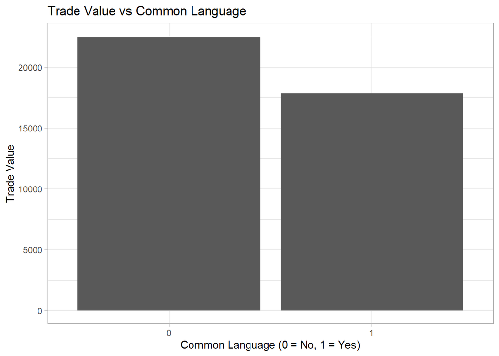

```r
# Impact of common language on trade value
TV_by_ComLag <- ggplot(commerce_NA_cl, aes(x = factor(comlang_off), fill= trade_value)) +
  geom_bar() + ggtitle("Trade Value vs Common Language") +
  xlab("Common Language (0 = No, 1 = Yes)") + ylab("Trade Value")+
  theme_light()
 TV_by_ComLag
```

The plot above shows that common language does not affect Nigeria’s trading relation with other countries within the region. As shown through the graph, there were more trade relations with countries with no common language than the ones with common language.

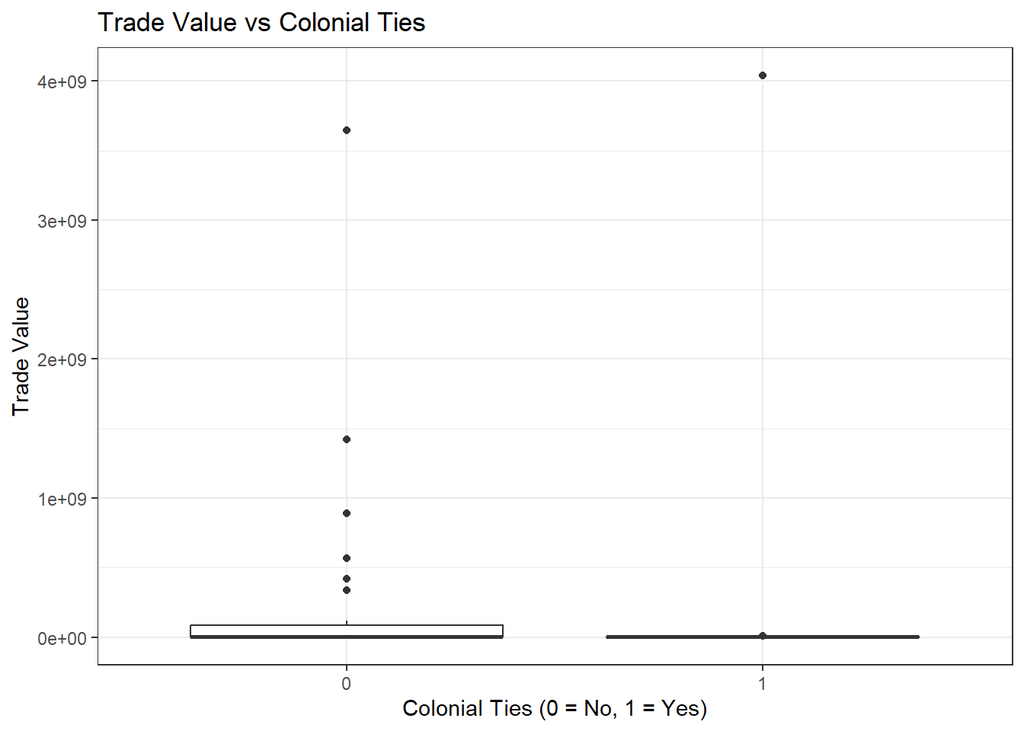

```r
# Impact of colonial ties on trade value
TV_by_ColMaster <- ggplot(commerce_NA_cl, aes(x = factor(comcol), y = trade_value)) +
  geom_boxplot() + ggtitle("Trade Value vs Colonial Ties") +
  xlab("Colonial Ties (0 = No, 1 = Yes)") + ylab("Trade Value")+
  theme_bw()
TV_by_ColMaster # this reveals that colonial master ties does not impact Nigeria's
```

```r
                #trading relation with other countries that were not colonized by same master
```

Similarly, we can see from above graph, that colonial master ties have no effect on the trading relationship Nigeria has with countries within the region. There are more trades with countries without colonial master ties

## Economic Indicators

We are analyzing here the relationship between trade values and economic indicators like GDP and GDP per capita.

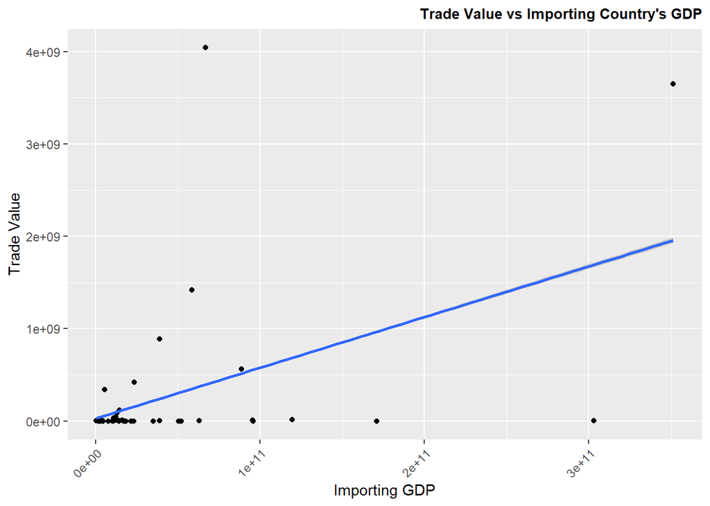

```r
# Trade value vs importing GDP
TV_by_GDP <- ggplot(commerce_NA_cl, aes(x = importing_gdp, y = trade_value)) +
  geom_point(alpha = 0.5) +
  geom_smooth(method = "lm") +
  ggtitle("Trade Value vs Importing Country's GDP") +
  xlab("Importing GDP") + ylab("Trade Value")+
  theme(axis.text.x = element_text(angle = 45, hjust = 1),
        plot.title = element_text(size = 10, face = "bold", hjust = 1))

TV_by_GDP # this shows a positive correlation btw the trade value and the countries GDP.
```

```r
#The higher the GDP, the higher the value of export from Nigeria
```

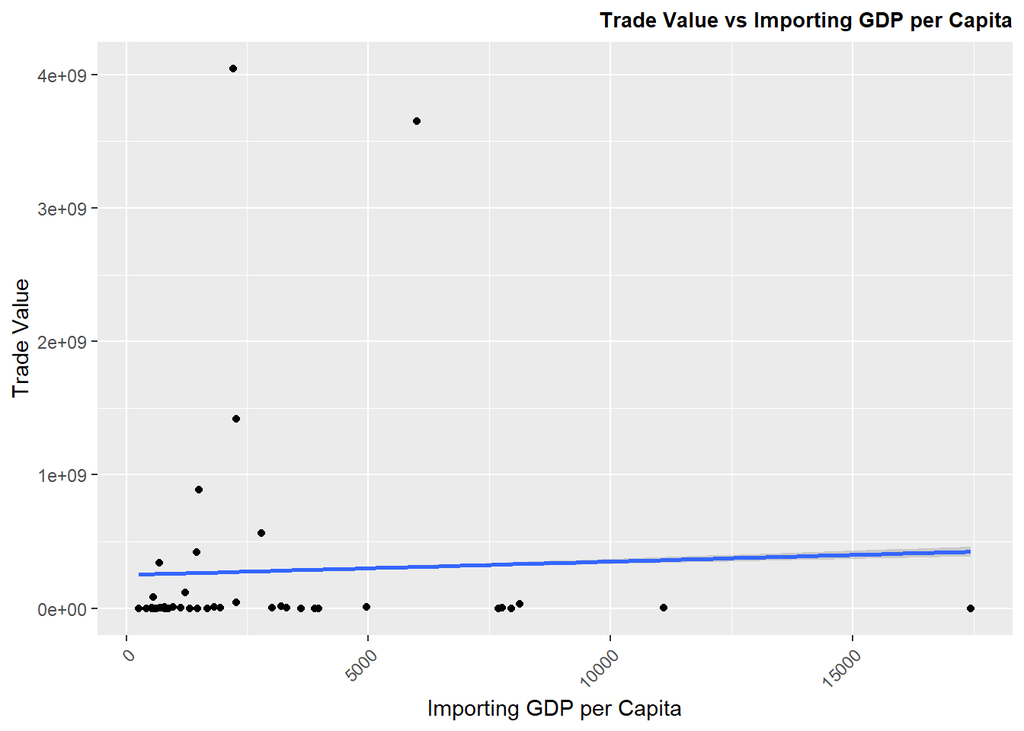

```r
# Trade value vs importing GDP per capita
TV_by_GDPerCapita <- ggplot(commerce_NA_cl, aes(x = importing_gdp_per_capita, y = trade_value)) +
  geom_point(alpha = 0.5) + geom_smooth(method = "lm") +
  ggtitle("Trade Value vs Importing GDP per Capita") +
  xlab("Importing GDP per Capita") + ylab("Trade Value")+
  theme(axis.text.x = element_text(angle = 45, hjust = 1),
        plot.title = element_text(size = 10, face = "bold", hjust = 1))
TV_by_GDPerCapita
```

As we can from both graphs above, that there is a positive correlation between the trade value and the countries GDP. The higher the GDP, the higher the value of export from Nigeria to those countries. This implies the importing countries have a higher purchasing power to place demands of products from Nigeria

To see the full report, see the notebook